# Song Summary

Michael_M michael.github@eipsoftware.com

Jan, 2020

# Song Summary

Data wrangling is documented in appendices code listings, clean_rankings.R and match_songs_ranks.R.

The overall procedure was extracting the lyrics for six artists from the website https://www.azlyrics.com including artist name, album name, year the album was released. Using the website https://www.billboard.com I extracted what was the peek rank and date of the peek rank for the song on the Billboard Hot 100 chart. The Billboard Hot 100 will be used as metric to determine the relative success of the song. While no metric can encapsulate how successful a song that all listeners would agree too, the chart is recognized by the music industry as reliable proxy.

### Load Library Files

```r
library(tibble ,quietly = TRUE, warn.conflicts = FALSE)
library(magrittr ,quietly = TRUE, warn.conflicts = FALSE)
library(dplyr ,quietly = TRUE, warn.conflicts = FALSE)
library(ggplot2 ,quietly = TRUE, warn.conflicts = FALSE)
library(NLP ,quietly = TRUE, warn.conflicts = FALSE)  #used by tm
library(tm ,quietly = TRUE, warn.conflicts = FALSE)

library(knitr ,quietly = TRUE, warn.conflicts = FALSE)
```

## Sample Record

Look at sample record in the data frame

```r
df_songs_lyrics <- readr::read_tsv(file.path(paste0(getwd(), "/df_song_lyrics.txt")))
# ----------------------------------------------------------------------------
# look at one of the values
# ----------------------------------------------------------------------------
glimpse(df_songs_lyrics[255,])
```

```
## Observations: 1
## Variables: 11
## $ album_name   <chr> "Take Me Home"
## $ album_year   <dbl> 2012
## $ song_title   <chr> "Heart Attack"
## $ artist       <chr> "One-Direction"
## $ peek_rank    <dbl> NA
## $ peek_date    <date> NA
## $ lyrics       <chr> "\nBaby, you got me sick,\nI don't know what I did,…
## $ album_decade <dbl> 2010
## $ charted      <chr> "Not Charted"
## $ NumberOne    <lgl> FALSE
## $ chart_group  <chr> "Not Charted"
```

### Data Dictionary

album_decade: decade album was released charted: did the album chart numberone: was it a number one song chart_group: was it a top ten, 11-100, or not-charted

## Visualizations

### Charted Songs by Artist

In our data sample there are 899 songs, by 6 artists with 83 top 10 songs, 22 being number one songs, and 230 other songs that were in the top 100.

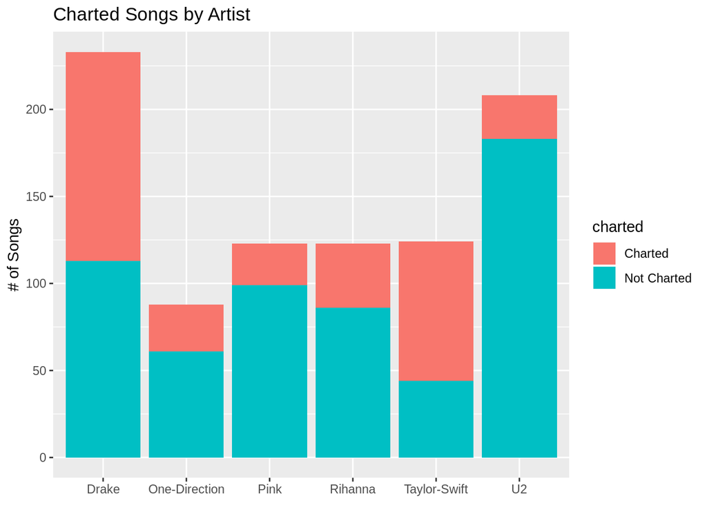

```r
library(ggplot2 ,quietly = TRUE, warn.conflicts = FALSE)

df_songs_lyrics %>%
  group_by(artist, charted) %>%
  summarise(number_of_songs = n()) %>%
  ggplot() +
  geom_bar(aes(x=artist
               ,y=number_of_songs
               ,fill = charted)
          ,stat = "identity") +
  labs(x=NULL, y="# of Songs")+
  ggtitle("Charted Songs by Artist")
```

### Songs by Artist and Chart Group

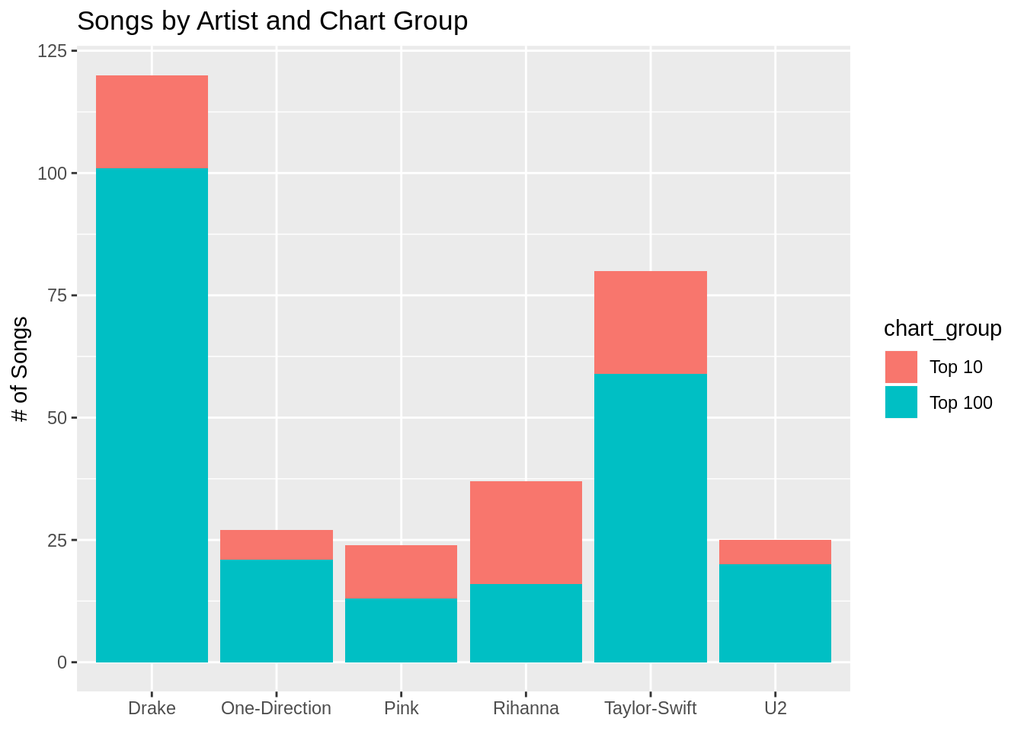

```r
df_songs_lyrics %>%
  group_by(artist, chart_group) %>%
  filter(peek_rank > 0) %>%
  summarise(number_of_songs = n()) %>%
  ggplot() +
  geom_bar(aes(x=artist
               ,y=number_of_songs
               ,fill = chart_group)
          ,stat = "identity") +
  labs(x=NULL, y="# of Songs") +
  ggtitle("Songs by Artist and Chart Group")
```

### Number 1 Songs by Artist

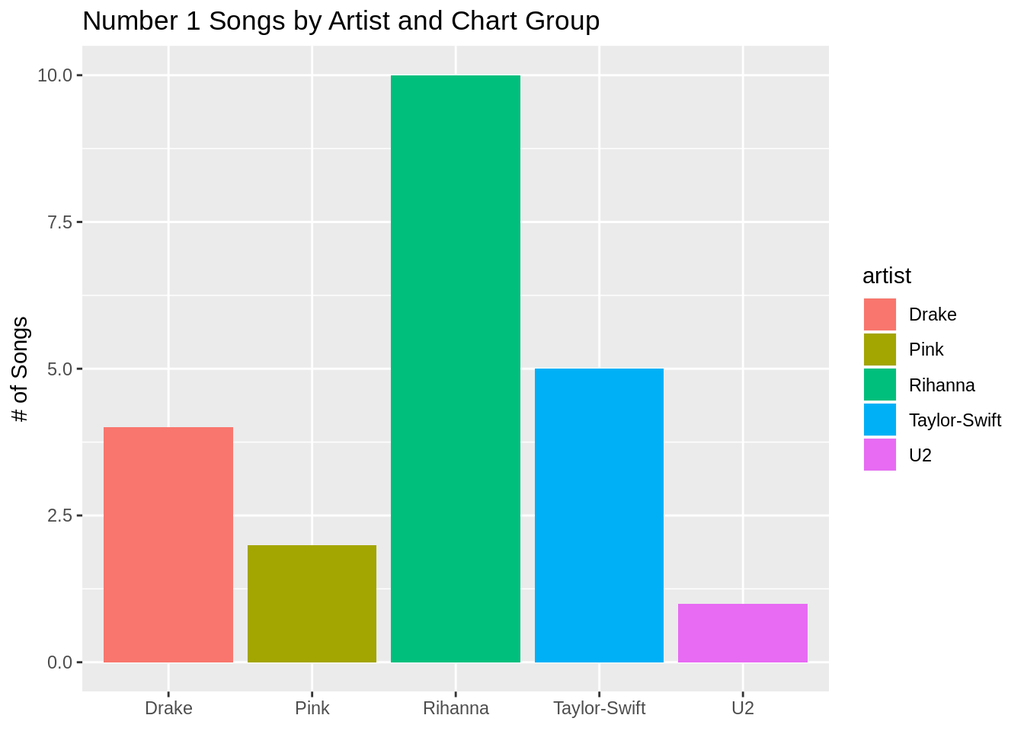

```r
df_songs_lyrics %>%
  group_by(artist) %>%
  filter(peek_rank == 1) %>%
  summarise(number_of_songs = n()) %>%
  ggplot() +
  geom_bar(aes(x=artist
               ,y=number_of_songs
               ,fill = artist)
          ,stat = "identity") +
  labs(x=NULL, y="# of Songs") +
  ggtitle("Number 1 Songs by Artist and Chart Group")
```

# Lyric Details

```r
library(tidytext ,quietly = TRUE, warn.conflicts = FALSE)
```

## Prepare the lyrics for analysis

In preparing the lyrics for analysis need to do the following.  
1. Remove any unique words, words in the source document that weren’t meant to be part of the lyrics 2. Ensure everything is in lower case 3. Remove any numbers or punctuation that was in the lyrics. The main reason is to remove apostrophes from contraction words, however it will also remove any commas or periods from the text. 4. Remove stop words from the lyrics 4. Strip any white space around the words. 5. Lastly remove any word that isn’t at least three characters in length.

Stop words are common words that we will remove before the text analysis. There is no common universal list of stop words, and it is subjective as to which stop words to remain and remove. In addition to the list of stop words listed in the snowball R package I have included some other words I wanted to remove because I don’t think they add value to the analysis.

```r
remove_words <- c("chorus", "repeat" ,"hey" ,"uh" ,"whoa"
                 )

scrubLyrics <- function(text_lyric){

  # convert to lower case, remove numbers, punctuation, stopwords, whitespace
  text_lyric <- text_lyric %>%
                  tolower() %>%
                  removeNumbers() %>%
                  removePunctuation() %>%
                  removeWords(stopwords("en")) %>%
                  stripWhitespace()

  return(text_lyric)

}

# copy into new dataframe
df_scrubbedLyrics <- df_songs_lyrics

# scrub the lyrics
df_scrubbedLyrics$lyrics <- lapply(df_scrubbedLyrics$lyrics, scrubLyrics)

# tokenize the lyrics
# expand the data frame so one word per row
# remove
df_scrubbedLyrics <- df_scrubbedLyrics %>%
  tidytext::unnest_tokens(t_words , lyrics) %>%
  filter(!t_words %in% remove_words) %>%
  filter(nchar(t_words) >=3 )
```

## Word Frequency

One of the features of songs we want to explore is, does the number of words in a song impact it’s performance? I will look at the total number of words in the songs to help determine.

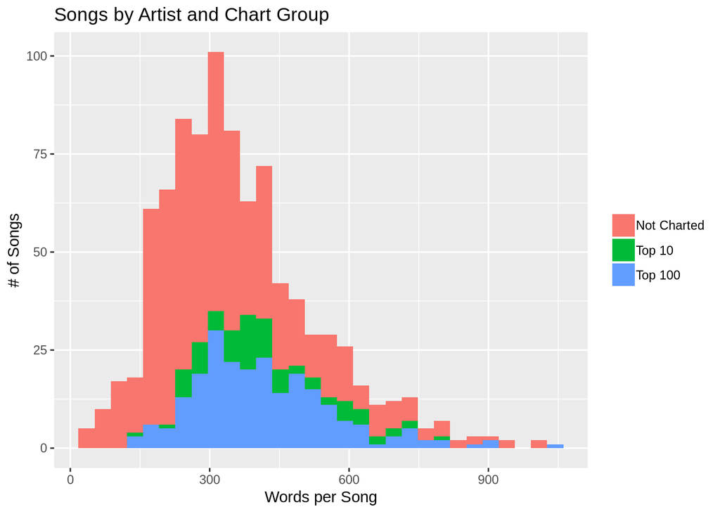

```r
df_all_words <- df_songs_lyrics %>%
  unnest_tokens(t_words , lyrics) %>%
  group_by(artist, song_title, chart_group) %>%
  summarise(word_count = n()) %>%
  arrange(desc(word_count))


df_all_words %>%
  ggplot() +
  geom_histogram( aes(x=word_count, fill=chart_group)) +
  labs(x="Words per Song", y="# of Songs") +
  ggtitle("Songs by Artist and Chart Group") +
  theme(legend.title = element_blank())
```

Compare the chart groups side by side

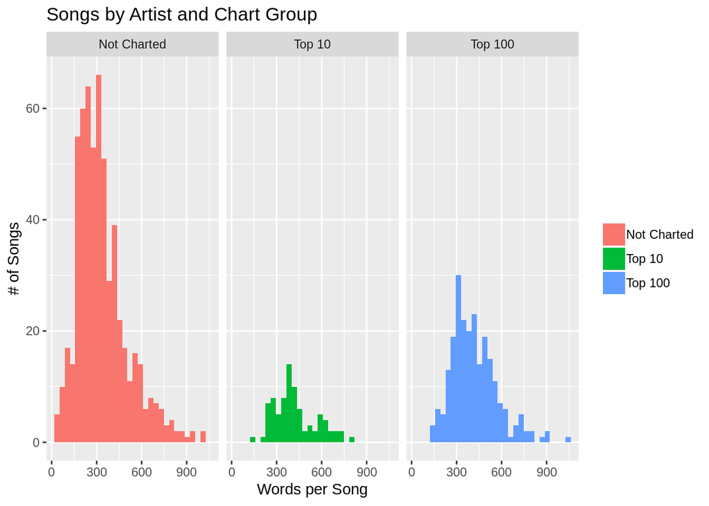

```r
df_all_words %>%
  ggplot() +
  geom_histogram( aes(x=word_count, fill=chart_group)) +
  facet_wrap(~chart_group, ncol = 3) +
  labs(x="Words per Song", y="# of Songs") +
  ggtitle("Songs by Artist and Chart Group") +
  theme(legend.title = element_blank())
```

## Most Common Words Used in Lyrics

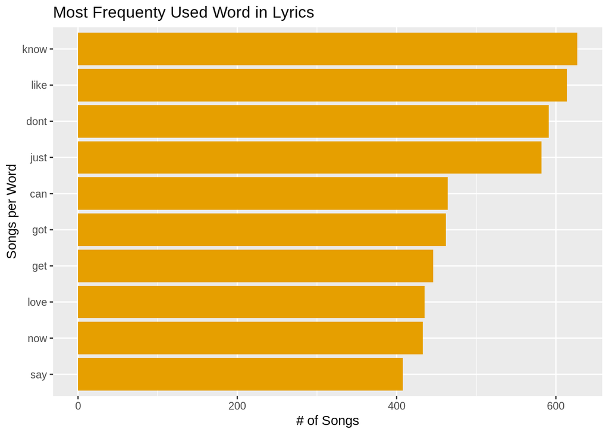

```r
df_scrubbedLyrics %>%
  distinct() %>%
  count(t_words, sort = TRUE) %>%
  top_n(10) %>%
  ungroup() %>%
  mutate(t_words = reorder(t_words, n)) %>%
  ggplot() +
    geom_col(aes(t_words, n), fill = "#E69F00") +
    coord_flip() +
    labs(x="Songs per Word", y="# of Songs") +
    ggtitle("Most Frequenty Used Word in Lyrics")
```

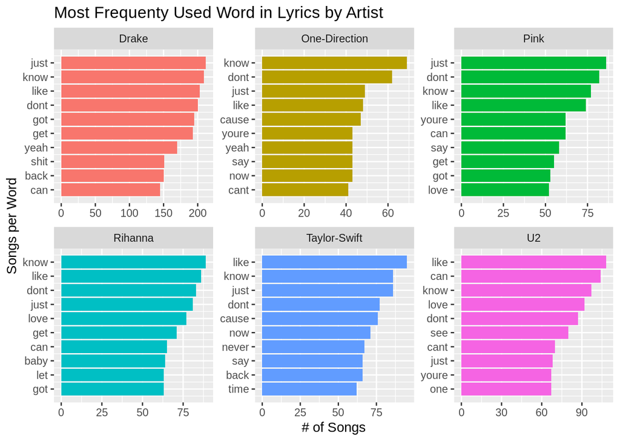

```r
words_by_artist <- df_scrubbedLyrics %>%
  distinct() %>%
  group_by(artist) %>%
  count(t_words, artist, sort = TRUE) %>%
  slice(seq_len(10)) %>%
  ungroup() %>%
  arrange(artist , n) %>%
  mutate(display_row = row_number())

words_by_artist %>%
    ggplot() +
    geom_col(aes(display_row, n, fill=artist)
             ,show.legend = FALSE) +
    coord_flip() +
    facet_wrap(~artist, scales = "free") +
    scale_x_continuous(labels = words_by_artist$t_words
                       ,breaks = words_by_artist$display_row) +
    labs(x="Songs per Word", y="# of Songs") +
    ggtitle("Most Frequenty Used Word in Lyrics by Artist")
```

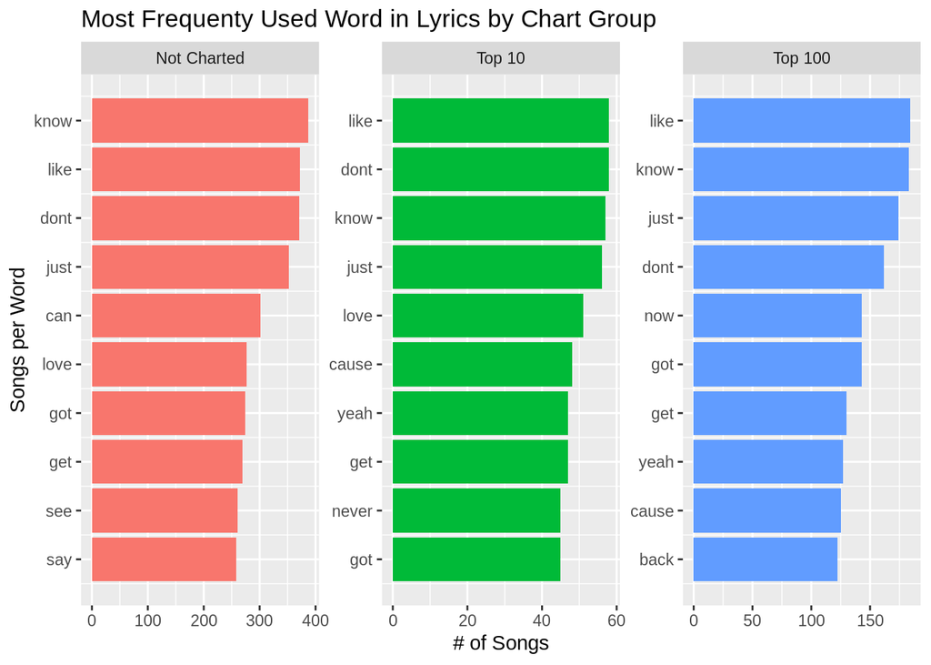

```r
words_by_chart_group <- df_scrubbedLyrics %>%
  distinct() %>%
  group_by(chart_group) %>%
  count(t_words, chart_group, sort = TRUE) %>%
  slice(seq_len(10)) %>%
  ungroup() %>%
  arrange(chart_group , n) %>%
  mutate(display_row = row_number())

words_by_chart_group %>%
    ggplot() +
    geom_col(aes(display_row, n, fill=chart_group)
             ,show.legend = FALSE) +
    coord_flip() +
    facet_wrap(~chart_group, scales = "free") +
    scale_x_continuous(labels = words_by_chart_group$t_words
                       ,breaks = words_by_chart_group$display_row) +
    labs(x="Songs per Word", y="# of Songs") +
    ggtitle("Most Frequenty Used Word in Lyrics by Chart Group")
```

# —————————————————————————-

# —————————————————————————-

```r
library(tibble ,quietly = TRUE, warn.conflicts = FALSE)
library(magrittr ,quietly = TRUE, warn.conflicts = FALSE)
library(dplyr ,quietly = TRUE, warn.conflicts = FALSE)
library(ggplot2 ,quietly = TRUE, warn.conflicts = FALSE)
```

```r
df_songs_lyrics %>%
  group_by(artist ,chart_group) %>%
  summarise(SongCount = n()) %>%
  reshape2::dcast(artist ~ chart_group, value.var = "SongCount") %>%
  `colnames<-` (c("artist","Not.Charted","Top.10","Top.100")) %>%
  mutate(Total = Top.10 + Top.100 + Not.Charted)
```

```
##          artist Not.Charted Top.10 Top.100 Total
## 1         Drake         113     19     101   233
## 2 One-Direction          61      6      21    88
## 3          Pink          99     11      13   123
## 4       Rihanna          86     21      16   123
## 5  Taylor-Swift          44     21      59   124
## 6            U2         183      5      20   208
```

```r
select_n_words <- 5000

df_top_words_per_group <-  df_scrubbedLyrics %>%
      group_by(chart_group) %>%
      mutate(group_word_count = n()) %>%
      group_by(chart_group, t_words) %>%
      mutate(word_count = n()
             ,word_percent = word_count / group_word_count) %>%
      select(t_words, chart_group, group_word_count, word_count, word_percent) %>%
      distinct() %>%
      filter(word_count >= 3) %>%
      arrange(desc(word_percent)) %>%
      top_n(select_n_words)
# remove words that are in more than one group
df_top_words <- df_top_words_per_group %>%
      ungroup() %>%
      group_by(t_words) %>%
      mutate(multi_group = n()) %>%
      filter(multi_group < 2) %>%
      select(chart_group, common_word = t_words)

# create lists of unique words by chart_group
words_not_charted <- lapply(df_top_words[df_top_words$chart_group == "Not Charted",], as.character)
words_top_100 <- lapply(df_top_words[df_top_words$chart_group == "Top 100",], as.character)
words_top_10 <- lapply(df_top_words[df_top_words$chart_group == "Top 10",], as.character)
```

```r
# 50, 10, 20
library(purrr)
library(tidyr)
```

```r
set.seed(8020)

test_lyric <- df_songs_lyrics %>%
    mutate(uid = seq(1,length(df_songs_lyrics$album_name))) %>%
    group_by(chart_group) %>%
    nest() %>%
    ungroup() %>%
    mutate(n = c(50,20,10)) %>%
    mutate(samp = map2(data, n, sample_n)) %>%
    select(-data) %>%
    unnest(samp)

train_lyric <- df_songs_lyrics %>%
    mutate(uid = seq(1,length(df_songs_lyrics$album_name)))

train_lyric <- anti_join(train_lyric, test_lyric, by='uid')
```

```r
# put to lower case, remove punctuation, and stop words
train_lyric$lyrics <- lapply(train_lyric$lyrics, scrubLyrics)
test_lyric$lyrics <- lapply(test_lyric$lyrics, scrubLyrics)

# build into tidy versions of the dataframes
# put into long data set
train_lyric_scrubbed <- train_lyric %>%
    select(-uid) %>%
    tidytext::unnest_tokens(t_words , lyrics)

test_lyric_scrubbed <- test_lyric %>%
    select(-n,-uid) %>%
    tidytext::unnest_tokens(t_words , lyrics)

lyric_features <- function(lyric){
    lf <- lyric %>%
    group_by(song_title) %>%
    mutate(word_frequency = n()
           , lexical_diversity = n_distinct(t_words)
           , lexical_density = lexical_diversity / word_frequency
           , reptition = word_frequency / lexical_diversity
           , song_avg_word_length = mean(nchar(t_words))
           , song_title_words = lengths(gregexpr("[A-z]\\W+",song_title)) +1L
           , song_title_length = nchar(song_title)
           , large_word_count = sum(ifelse((nchar(t_words)>7),1,0))
           , small_word_count = sum(ifelse((nchar(t_words)<3),1,0))
           , top_10_word_count
              = sum(ifelse(t_words %in% words_top_10$common_word,15,0))
           , top_100_word_count
              = sum(ifelse(t_words %in% words_top_100$common_word,5,0))
           , uncharted_word_count
              = sum(ifelse(t_words %in% words_not_charted$common_word,5,0))
           ) %>%
      select(-t_words) %>%
      select(album_name             #1. chr
             , song_title           #2. chr
             , artist               #3. chr
             , peek_date            #4. date
             , charted              #5. chr
             , NumberOne            #6. bool
             , peek_rank            #7. num
             , album_year           #8. num
             , album_decade         #9. num
             , word_frequency       #10. num
             , lexical_diversity    #11. num
             , lexical_density      #12. num
             , reptition            #13. num
             , song_avg_word_length #14. num
             , song_title_words     #15. num
             , song_title_length    #16. num
             , large_word_count     #17. num
             , small_word_count     #18. num
             , top_10_word_count    #19. num
             , top_100_word_count   #20. num
             , uncharted_word_count #21. num
             , chart_group          #22. factor 3 levels
             ) %>%

      distinct() %>%
      ungroup()

    lf$chart_group <- as.factor(lf$chart_group)
    return(lf)
}

train_data_fe <- lyric_features(train_lyric_scrubbed)
test_data_fe <- lyric_features(test_lyric_scrubbed)
```

```r
library(mlr ,quietly = TRUE, warn.conflicts = FALSE)
```

## Normalize the datasets

```r
col_nm <-c("word_frequency","lexical_diversity","reptition"
           ,"song_avg_word_length","song_title_words","song_title_length"
           ,"large_word_count","small_word_count","top_10_word_count"
           ,"top_100_word_count","uncharted_word_count"
           )
train_data_nm <- normalizeFeatures(train_data_fe
                                   ,method = "standardize"
                                   ,cols=col_nm
                                   ,range=c(0,1)
                                   ,on.constant = "quiet")
test_data_nm <- normalizeFeatures(test_data_fe
                                   ,method = "standardize"
                                   ,cols=col_nm
                                   ,range=c(0,1)
                                   ,on.constant = "quiet")
```

### Create the Classifiers

```r
# will use a variety of models to see if any of the models
# preform better with lyrics

models = list(
      makeLearner("classif.naiveBayes", id = "Naive Bayes")
      , makeLearner("classif.lda", id = "LDA")
      , makeLearner("classif.ksvm", id = "SVM")
      , makeLearner("classif.knn", id = "KNN")
      , makeLearner("classif.rpart", id = "RPART", predict.type = "prob")
      , makeLearner("classif.randomForest", id = "Random Forest", predict.type = "prob")
      , makeLearner("classif.xgboost", id = "XG Boost", predict.type = "prob")
      , makeLearner("classif.nnet", id = "Neural Net", predict.type = "prob")
)
# use cross fold validation
cfold <- makeResampleDesc("CV" ,iters = 10, stratify = TRUE)
```

```r
# make classifiers
exclude_cols = c(1:7)
train_clf <- makeClassifTask(id="Lyrics"
                             , data = train_data_nm[-exclude_cols]
                             , target = "chart_group"
                             )
test_clf <- makeClassifTask(id="Lyrics"
                             , data = test_data_nm[-exclude_cols]
                             , target = "chart_group"
                             )
lyric_train_benchmark <- benchmark(models
                         ,tasks = train_clf
                         ,resamplings = cfold
                         ,measures = list(acc, timetrain)
                         ,show.info = FALSE
                         )
lyric_train_benchmark
```

```
##   task.id    learner.id acc.test.mean timetrain.test.mean
## 1  Lyrics   Naive Bayes     0.8706484              0.0039
## 2  Lyrics           LDA     0.8560566              0.0119
## 3  Lyrics           SVM     0.8756448              0.0771
## 4  Lyrics           KNN     0.7680821              0.0001
## 5  Lyrics         RPART     0.9011682              0.0056
## 6  Lyrics Random Forest     0.9109544              0.3485
## 7  Lyrics      XG Boost     0.8999476              0.0038
## 8  Lyrics    Neural Net     0.6544656              0.0055
```

### Plot Training Results

[figure not shown]

```r
plotBMRSummary(lyric_train_benchmark)
```

### Confustion Matrix

```r
predictions_train <- getBMRPredictions(lyric_train_benchmark)
calculateConfusionMatrix(predictions_train$Lyrics$`Random Forest`)$result
```

```
##              predicted
## true          Not Charted Top 10 Top 100 -err.-
##   Not Charted         524      0      12     12
##   Top 10               21     50       2     23
##   Top 100              37      1     172     38
##   -err.-               58      1      14     73
```

### Feature Importance

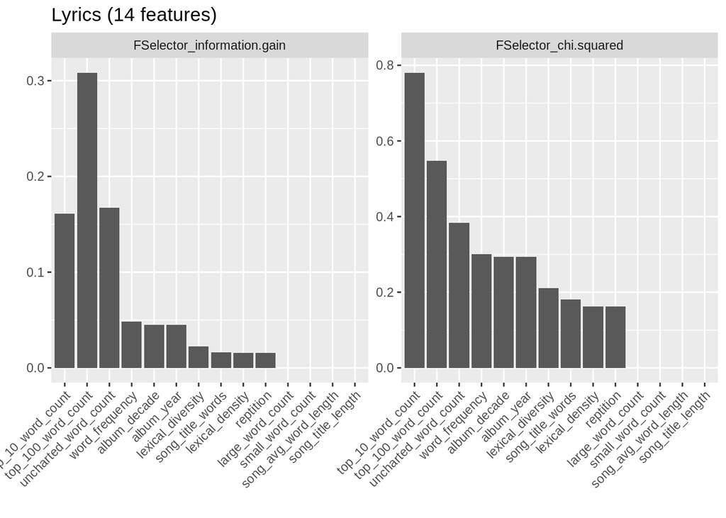

```r
# feature importance
feature_importance <- generateFilterValuesData(task = train_clf
                                               ,method = c("FSelector_information.gain", "FSelector_chi.squared")
                                               )
plotFilterValues(feature_importance,n.show = 20)
```

## Testing the Model

```r
rf_model <- train("classif.randomForest",train_clf)
result_rf <- predict(rf_model, test_clf)
performance(result_rf, measures = acc)
```

```
##   acc
## 0.925
```

```r
calculateConfusionMatrix(pred = result_rf)
```

```
##              predicted
## true          Not Charted Top 10 Top 100 -err.-
##   Not Charted          50      0       0      0
##   Top 10                4      6       0      4
##   Top 100               2      0      18      2
##   -err.-                6      0       0      6
```